# Caminhada Aleatória

Esley Caminhas Ferreira

27/05/2023

# **Experimento Caminhada Aleatória**

[figure not shown]

## **Objetivo**

Introduzir os visitantes da mostra a ideia de caminhada aleatória e estimular o pensamento probabilístico dos mesmos.

## **Motivação**

Um marcador é posto na origem de uma malha quadriculada, seu movimento funciona da seguinte maneira, uma moeda honesta é lançada:

- Se cair cara, o marcador avança diagonalmente uma unidade para a direita.
- Se cair coroa, o marcador avança diagonalmente uma unidade para a esquerda.

Com isso surge a seguinte pergunta: É possível prever qual será a posição final do marcador na malha?

## **Construção**

Para esse experimento são necessários:

- Uma malha quadriculada, para ser mais intuitiva a malha usada pode ser composta somente dos caminhos possíveis.
- Um marcador, qualquer item que possa ser usado para marcar a posição atual durante o experimento. Ex. Moeda, bala, peça de xadrez, etc.
- Uma moeda honesta.

## **Execução**

1. É perguntado aos visitantes em que casa da última linha da malha eles acreditam que o marcado irá terminar.
2. Em seguida o marcador é posicionado na origem da malha e a moeda é jogada.
3. Dependendo do resultado o marcado será movido para uma das próximas casas.
4. Assim sucessivamente até o marcador chegar a última linha.
5. Ao final é explicada a ideia por traz do experimento e o porque da moeda acabar mais nas casas do centro do que nas das bordas.

## **Teoria**

### Caminhada aleatória no plano

Prever a posição final de forma consistente é impossível pois o marcador se move de maneira incerta, nesse momento usamos a probabilidade como ferramenta para nos ajudar a quantificar essa incerteza.

Seja $X$ uma variável aleatória que assume valores 1 e -1 com mesma probabilidade. Tendo a seguinte função massa de probabilidade.

$$f(x) = \begin{cases}
\frac{1}{2},
\ \
x \ =
\ \ \
1
\\
\frac{1}{2},
\ \
x \ = -1
\end{cases}$$

Com valor esperado.

$$E[X] = \sum_{x \in Rx} x \ f(x) = -\frac{1}{2} + \frac{1}{2} = 0$$

Usando $X$ podemos descrever o movimento do marcador na malha, ou nesse caso no plano cartesiano, da seguinte maneira:

$$(0,0)
\rightarrow
(1, \ X_1)
\rightarrow
(2, \ X_1+X_2)
\rightarrow
(3, \ X_1+X_2+X_3)
\rightarrow
... \rightarrow
(n, \ X_1+X_2+X_3+...+X_n)$$

Portanto $(n, \ X_1+X_2+X_3+...+X_n)$ representa posição final do marcador depois de $n$ passos, logo para encontrarmos o valor esperado dessa última posição devemos encontrar:

$$E[X_1+X_2+X_3+...+X_n] = E[X_1]+E[X_2]+E[X_3]+...+E[X_n]$$
E como cada $X_i$, $1 \leq i \leq n$, segue a mesma distribuição $X$.

$$E[X_1]+E[X_2]+E[X_3]+...+E[X_n] = nE[X] = 0$$
Logo o valor esperado para a última posição do marcador depois de $n$ lançamentos é $(n,0)$. Esse resultado nos mostra que o marcador tem maior probabilidade de acabar em casas próximas ao centro.

Utilizando dessa ideia podemos simular as caminhadas.

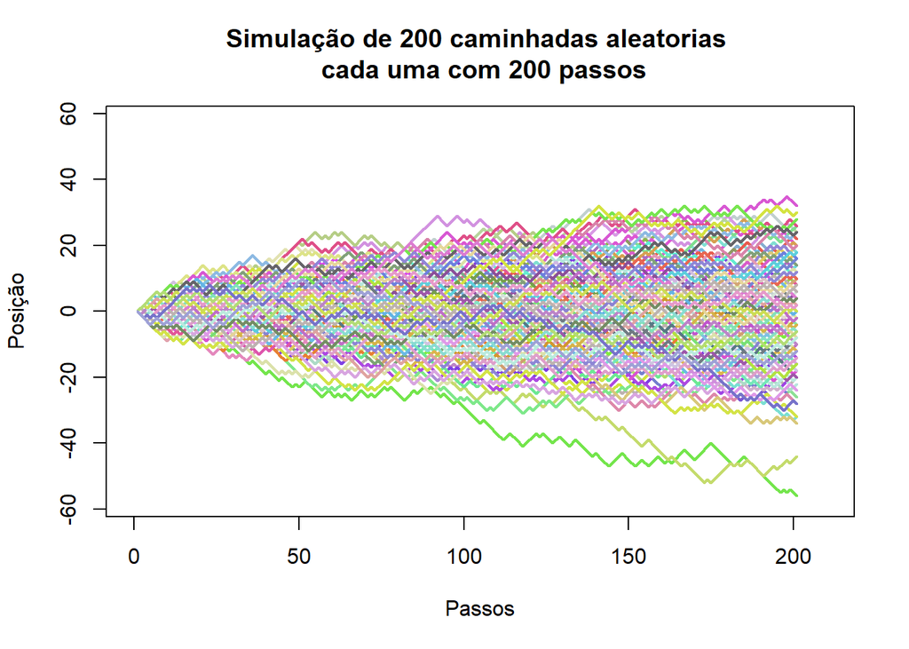

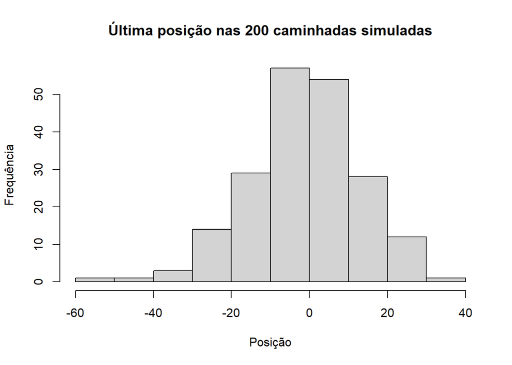

### **Relação com o tringulo de pascal e a distribuição binomial**

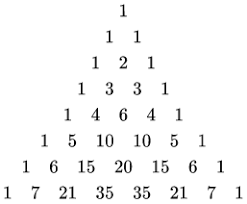

Triangulo de Pascal (até a oitava linha).

Ao calcularmos a probabilidade do marcador visitar determinada casa da malha podemos identificar um padrão, considerando a origem com probabilidade 1 o resto das casas da primeira linha com probabilidade 0, a probabilidade de dada casa ser visitada pelo marcador é a soma das probabilidades das casas anteriores adjacentes a ela multiplicadas por $\frac{1}{2}$.

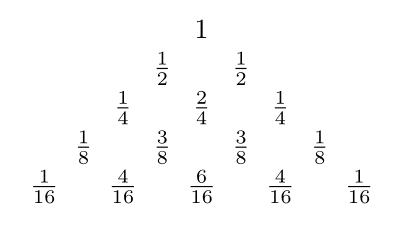

Probabilidade de visita de cada casa (até a quinta linha).

Usando da semelhança dessa sequência com o triangulo de pascal podemos utilizar o coeficiente binomial para encontrar a probabilidade de cada casa ser visitada, denotando por $F_{u,v}$ o evento “moeda visitar a u-ésima casa da v-ésima linha”, temos:

$$\begin{equation}
P(F_{u,v})={v \choose u}\frac{1}{2^v}={v \choose u} \left( \frac{1}{2} \right)^v
\end{equation}$$

Com ${v \choose u} = \frac{v!}{u!(v-u)!}$.

Com as posições de linha e coluna sendo contadas a partir de zero e $0 \leq u \leq v$, nessa equação podemos perceber que quanto mais próxima das bordas, dos valores extremos, menor é a probabilidade da casa ser visitada.

O último termo dessa igualdade pode ser escrito como sendo a probabilidade da variável aleatória $X$ ser igual a $u$ quando $X$ tem distribuição binomial com os parametros $n=v$ e $p=\frac{1}{2}$.